# Brook Trout Abundance and Extreme Flows - Results

Annalise Blum

12/20/2016

## Research questions

1. How do seasonal extremes in climate and streamflow affect brook trout young-of-the-year abundance? *To answer* look at sign and magnitude of coefficients (effect sizes) in models of abundance
2. Which seasonal weather metrics (seasinal averages, daily maximum precipitation or daily maximum temperature) and flow metrics (magnitude, duration, or average flow) are most useful in explaining next summer brook trout abundance? *To answer* look at goodness of fit (lowest AIC, other metrics?) of models with competing metrics
3. Are there thresholds in these at which there is a clear change in abundance? *To answer* identify cut-offs with regression trees (other methods? piece-wise) and evaluate whether dummies for above or below threshold

## First, some exploratory plots

### YOY abundance over the 29 study years (1982-2010)

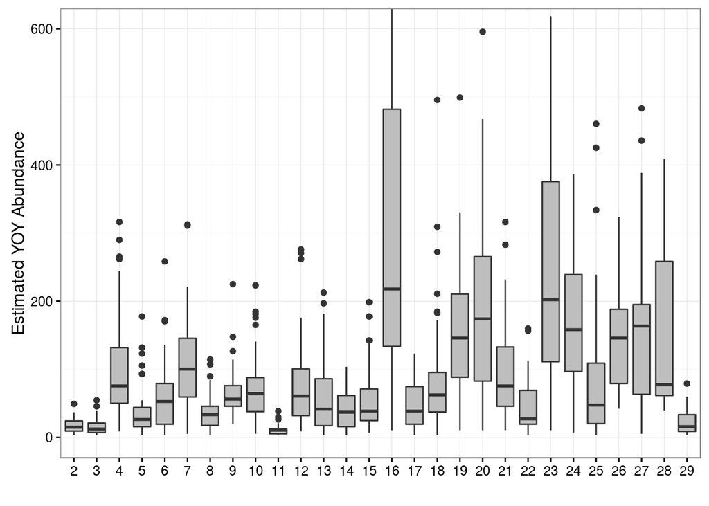

*7 abundances > 600 not shown*

### Variability across sites of seasonal precipitation

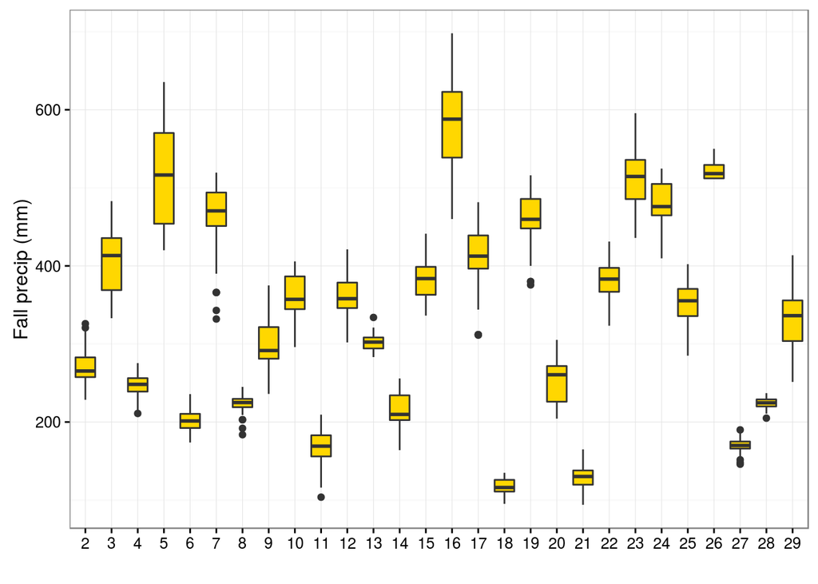

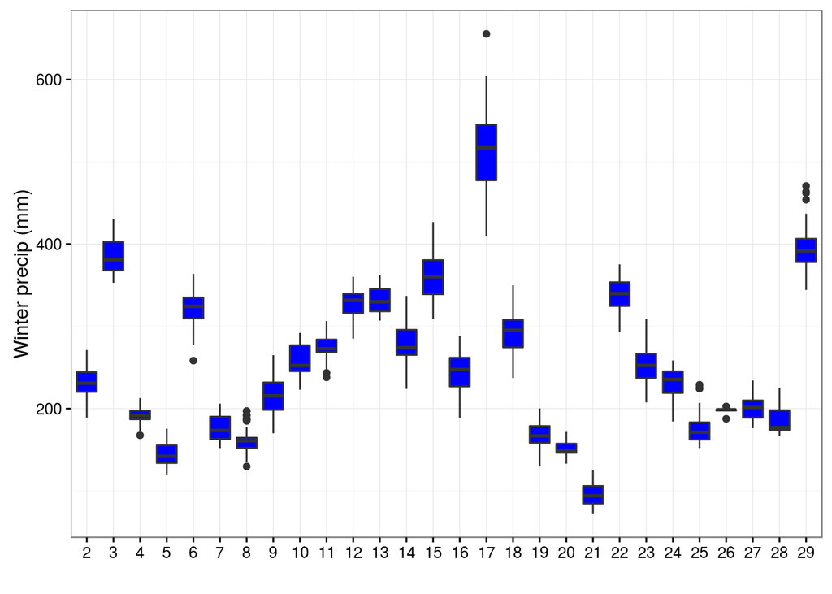

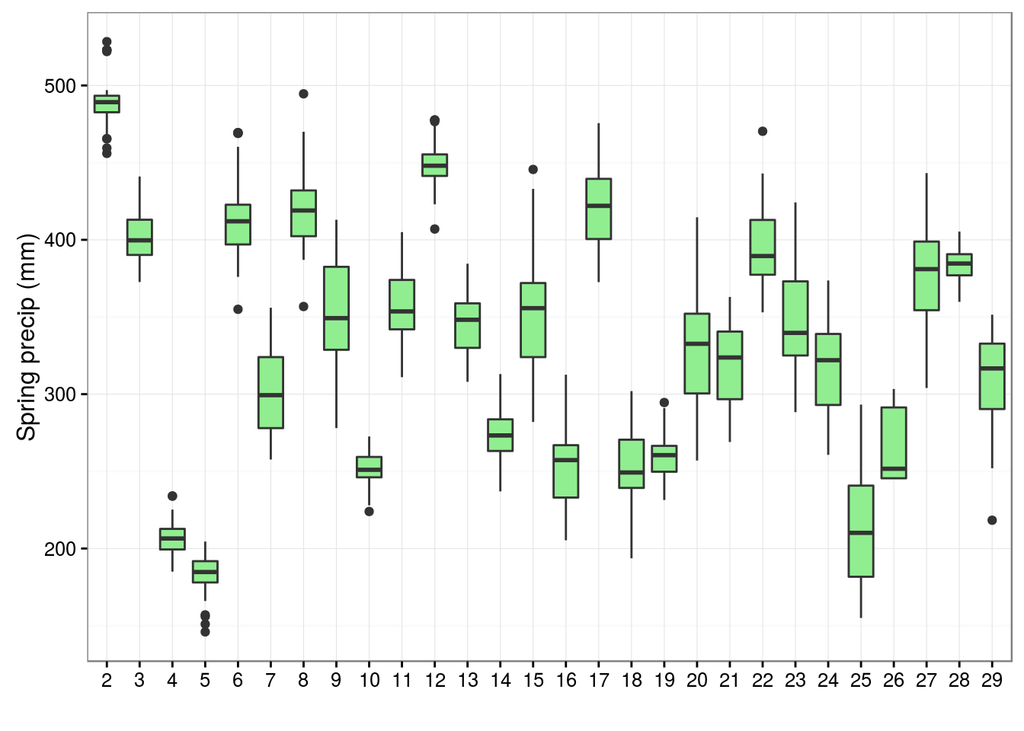

*Year 1 missing because I used year as seasons before sampling and I need to get precipitation data for 1981*

### Correlation of variables

High correlation between daily maximum temperature variables across seasons and winter and spring flows

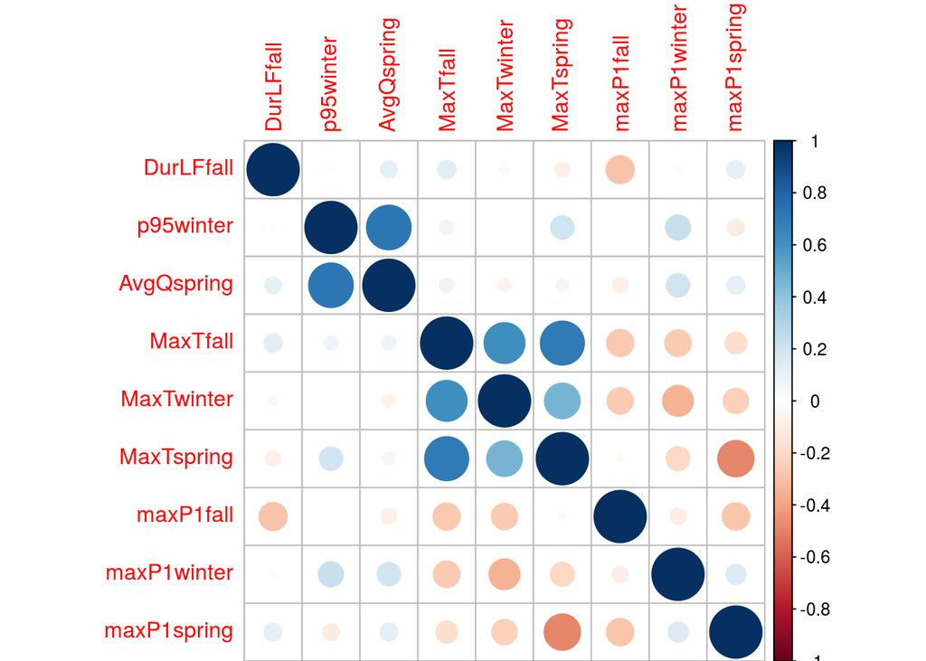

### Plots with contors: patterns in abundance most clear with extreme winter flow and max daily fall precip

Seasonal precipitation in fall and winter vs abundance

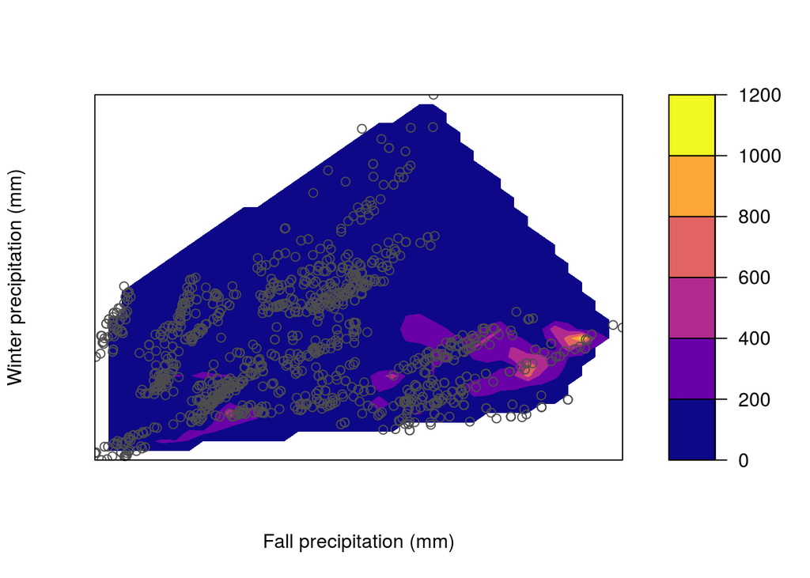

Extreme precipitation in fall and winter vs abundance

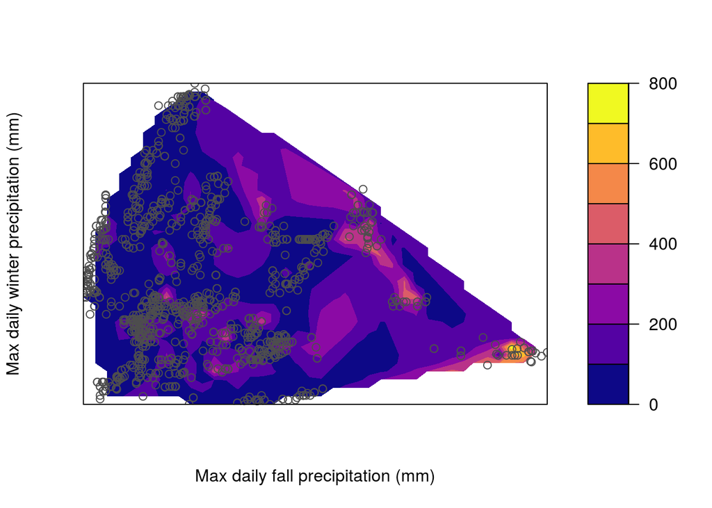

Extreme precipitation in fall and winter high flows vs abundance

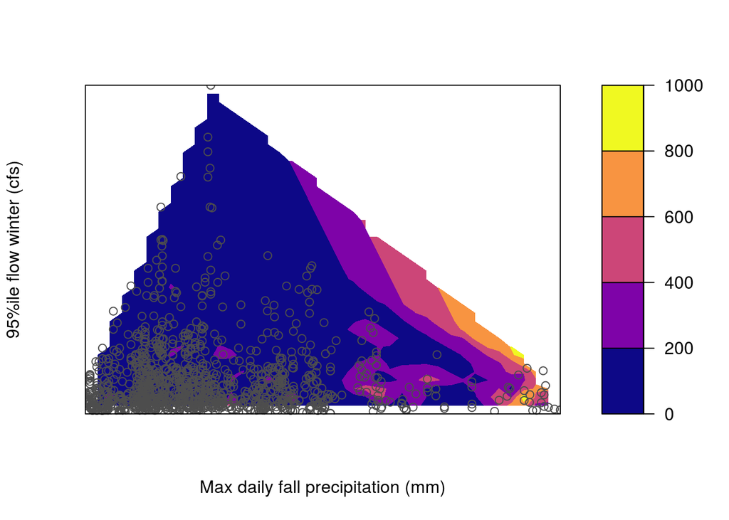

### Effect size from MCMC samples in JAGS model